# QC Analysis of ICB_Ravi mae

Nasim Bondar Sahebi

2023-11-07

# Install and Load Libraries

```r
library(ggplot2)
library(dplyr)
library(MultiAssayExperiment)
library(limma)
library(EnhancedVolcano)
library(DT)
library(RColorBrewer)
library(readr)
```

# Data Loading and Preparation

## Load Gene Expression Data

#### Data Overview

- **Study Reference**: [PubMed ID 37024582](https://pubmed.ncbi.nlm.nih.gov/37024582/)
- **Patient Count (RNA)**: 152
- **Treatment Details**: **PD-1/PD-L1**: 130 patients **IO+chemo**: 2 patients **IO+combo**: 16 patients **Not Available (NA)**: 4 patients

Load multiassay .rds file, extract clinical, expression data, and annotations; prepare gene expression data for analysis.

```r
# Load your multiassay result and extract clinical data , expression data and annotation

#load mae obj
mae <- readRDS("~/BHK lab/Ravi_version2/data/ICB_Ravii.rds")

#extract Clinical data
clin <- data.frame(colData(mae))

#extract the expression data
expr <- assays(mae)[["expr"]]

#extracting the annotation
annot <- data.frame(rowData(mae@ExperimentList$expr))

# Display first few rows of the dataset
expr[1:10,1:6]
```

```
##                    SU2CLC_CLE_NIVO10 SU2CLC_CLE_NIVO18 SU2CLC_CLE_NIVO19
## ENSG00000000003.14       4.052615868         3.6696278          3.672324
## ENSG00000000005.5       -9.965784285        -0.7881455          1.081217
## ENSG00000000419.12       3.461554752         6.6295125          6.150718
## ENSG00000000457.13      -9.965784285         3.4745788          3.188937
## ENSG00000000460.16       0.002623318         3.5483626          3.715553
## ENSG00000000938.12      -2.278233634         2.5595016          2.720035
## ENSG00000000971.15       5.091627909         6.0176748          8.152011
## ENSG00000001036.13       3.083116334         4.1588460          4.491680
## ENSG00000001084.10       3.981788735         5.3330372          5.467361
## ENSG00000001167.14       2.408220011         4.6639708          4.993702
##                    SU2CLC_CLE_NIVO2 SU2CLC_CLE_NIVO20 SU2CLC_CLE_NIVO21
## ENSG00000000003.14        2.8429969          2.266295        -0.7859324
## ENSG00000000005.5        -0.8971081         -4.558704         1.6965459
## ENSG00000000419.12        6.6629603          5.466415         5.8838823
## ENSG00000000457.13        3.9756485          2.905430         5.3539831
## ENSG00000000460.16        5.0464692          3.926426         5.1050075
## ENSG00000000938.12        3.3639140          4.288949         1.2005357
## ENSG00000000971.15        7.2536395          6.596234         6.5724820
## ENSG00000001036.13        4.7155255          4.612193         1.9852308
## ENSG00000001084.10        4.9392642          4.116681         6.2587601
## ENSG00000001167.14        5.1349848          4.010932         3.9886392
```

# Principal Component Analysis (PCA)

## Objective

Perform PCA on gene expression data to assess variation across different research centers.

### Data Preparation

Following the methodologies outlined in the “RNA-seq differential expression analysis” section of the referenced paper, the following steps were taken to prepare our gene expression data for Principal Component Analysis (PCA):

1. **Restrict to protein-coding genes.**
2. **Convert expression data**: Convert from `log2(TPM+0.001)` to `log2(TPM+1)` for consistency.
3. **Remove low/zero expression genes**: Keep genes with expression at `log2TPM ≥ 0.5` across at least 30% of samples.

```r
# Step 1: Restrict to Protein-Coding Genes
# Filter out non-protein-coding transcripts for focused analysis
annot_proteincoding <- annot[annot$gene_type == "protein_coding",] # 1586protein coding genes as mention in paper too!
expr <- expr[rownames(expr) %in% rownames(annot_proteincoding),]

# Step 2: Normalize Expression Data
# Convert from expr (log2(TPM + 0.001)) to standard log2(TPM + 1) format
expr_original <- 2**expr - 0.001
expr <- log2(expr_original + 1)

# Step 3: Filter Low/Zero Expression Genes
# Retain genes expressed in at least 30% of the samples (as per study criteria)
threshold_samples <- ceiling(ncol(expr) * 0.3)
genes_above_threshold <- rowSums(expr >= 0.5)
expr <- expr[genes_above_threshold >= threshold_samples, ]

# Step 4: Transpose Data for PCA
# Position samples as rows and genes as columns
expr_m <- t(expr)
```

### Perform PCA

```r
# Calculate PCA
pc <- prcomp(expr_m, center = TRUE, scale. = TRUE)

# Calculate and print the percentage of variance explained by each principal component
var_res <- pc$sdev^2 / sum(pc$sdev^2) * 100
var_res <- round(var_res, 2)  # Round to 2 decimal places

print(var_res)
```

```
##   [1] 27.89  5.57  4.07  3.75  3.32  2.94  2.57  2.19  2.05  2.03  1.93  1.72
##  [13]  1.68  1.60  1.53  1.39  1.37  1.25  1.14  1.04  0.93  0.88  0.85  0.80
##  [25]  0.76  0.69  0.64  0.63  0.61  0.57  0.55  0.54  0.50  0.49  0.47  0.45
##  [37]  0.43  0.42  0.42  0.40  0.39  0.38  0.37  0.36  0.35  0.33  0.33  0.32
##  [49]  0.31  0.30  0.30  0.29  0.29  0.28  0.28  0.27  0.26  0.25  0.25  0.25
##  [61]  0.24  0.24  0.24  0.23  0.22  0.22  0.22  0.22  0.21  0.20  0.20  0.20
##  [73]  0.19  0.19  0.19  0.18  0.18  0.17  0.17  0.17  0.17  0.17  0.16  0.16
##  [85]  0.16  0.15  0.15  0.15  0.15  0.14  0.14  0.14  0.14  0.13  0.13  0.13
##  [97]  0.13  0.13  0.12  0.12  0.12  0.12  0.11  0.11  0.11  0.11  0.11  0.11
## [109]  0.10  0.10  0.10  0.10  0.10  0.09  0.09  0.09  0.09  0.09  0.09  0.08
## [121]  0.08  0.08  0.08  0.08  0.07  0.07  0.07  0.07  0.07  0.07  0.06  0.06
## [133]  0.06  0.06  0.06  0.06  0.06  0.06  0.05  0.05  0.05  0.05  0.05  0.05
## [145]  0.04  0.04  0.04  0.04  0.03  0.03  0.03  0.00
```

### Clinical Data Processing

- Subseting clinical data

```r
# Subsetting 'clin' data frame to include only 'patientid' and 'Institution' columns

clin_subset <- clin[, c("patientid", "Institution")]
clin_subsetresponse <-clin[, c("patientid", "response")]
```

### Merge PCA and Clinical Data

```r
# Merge PCA results with clinical data
pcx <- data.frame(pc$x)
pcx$patientid <- rownames(pcx)
pcx$patientid <- gsub("\\_", "-", pcx$patientid)

pcx_merge <- merge(pcx, clin_subset, by="patientid")
rownames(pcx_merge) <- pcx_merge[,1]
pcx_merge <- pcx_merge[,-1] # institution column is added
```

# Visualization

### Bar Plot

- Create a bar plot to visualize variance by each principal component.

The bar plot displays PC1 as the longest, explaining the most variance, while subsequent bars (PC2, PC3, etc.) become progressively shorter, indicating diminishing variance.

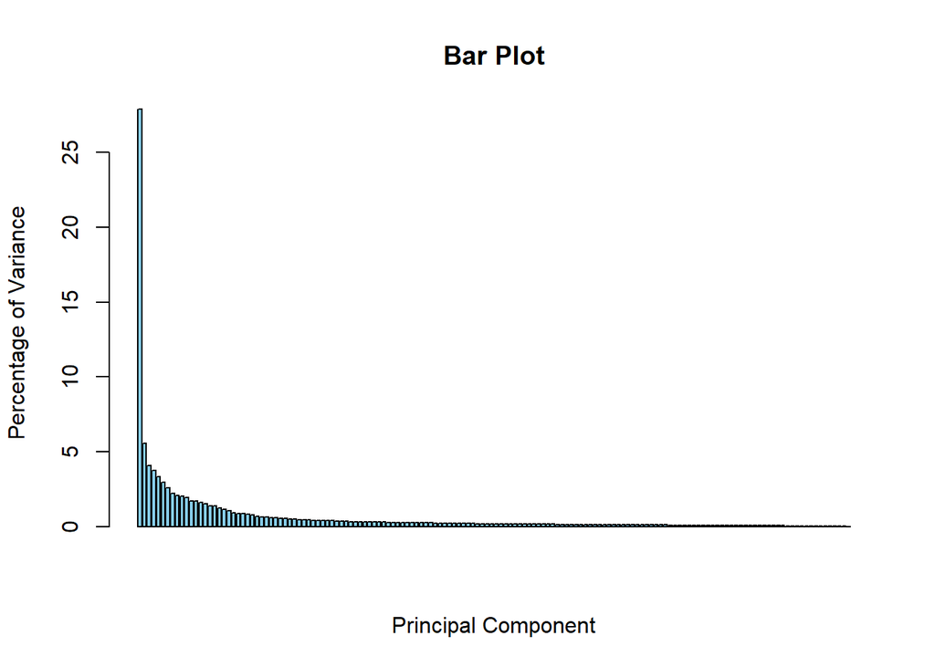

```r
#To find the largest PC of data

barplot(var_res, main="Bar Plot", xlab="Principal Component", ylab="Percentage of Variance ", col="skyblue")
```

### 1. PCA Results Plot

PCA on gene expression data, shows that the ‘Institution’ factor has no significant effect on gene expression data sampling. (no Batch effect has been detected)

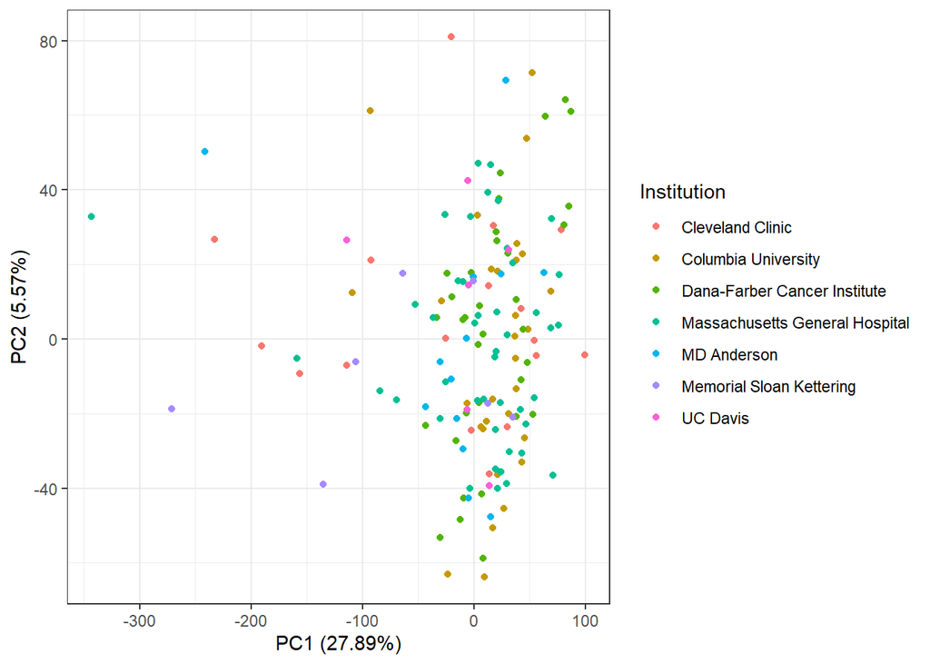

```r
# Create labels for the plot
xlab_text <- paste("PC1 (", var_res[1], "%)", sep = "")
ylab_text <- paste("PC2 (", var_res[2], "%)", sep = "")

# Plot PCA results
ggplot(pcx_merge, aes(PC1, PC2, color = Institution)) +
  theme_bw() +
  geom_point() +
  labs(x = xlab_text, y = ylab_text)
```

#### 2.Limma approach

-Used to find the differentially expressed genes between responders and non-responders

```r
# Remove rows with missing values in response and expression data
na_response <- is.na(clin$response)

# Create filtered response data by excluding rows with response missing values
filtered_response <- clin$response[!na_response]

# Access the expression data and exclude rows with missing response values
filtered_expression <- expr[, !na_response] #27 rows removed due to missing response values


# Create a design matrix using the filtered response data
design <- model.matrix(~ filtered_response)

# Fit a linear model using the filtered expression data and the design matrix
fit <- lmFit(filtered_expression, design)

# Perform eBayes analysis
fit <- eBayes(fit)

# To display the results in a table format, you can use 'datatable'
datatable(topTable(fit))
```

|  | logFC | AveExpr | t | P.Value | adj.P.Val | B |
| --- | --- | --- | --- | --- | --- | --- |
| ENSG00000185614.4 | -0.6116952128683557 | 2.32434976260165 | -3.468909573549257 | 0.0007090195517210969 | 0.9992129294673874 | -3.230312560587042 |
| ENSG00000185972.5 | -0.4590248749358119 | 0.9403709636139369 | -3.337110991246714 | 0.001103783711477251 | 0.9992129294673874 | -3.33603830153457 |
| ENSG00000239998.5 | -0.5499332978713932 | 1.490819348037644 | -3.332684634560968 | 0.001120075809244331 | 0.9992129294673874 | -3.339537856634623 |
| ENSG00000178031.16 | -0.7380496143106563 | 2.003513190515744 | -3.258415354715169 | 0.0014292750010902 | 0.9992129294673874 | -3.397750151269442 |
| ENSG00000135312.6 | -0.3608795047821114 | 0.5610930020938042 | -3.207196251306353 | 0.00168705264152154 | 0.9992129294673874 | -3.437331937840406 |
| ENSG00000181744.8 | -0.5914628133594477 | 2.920691817221539 | -3.166740662441164 | 0.001920561949484323 | 0.9992129294673874 | -3.468265311991944 |
| ENSG00000106829.18 | -0.475023134380869 | 3.906245536483258 | -3.166051031675954 | 0.001924791030840502 | 0.9992129294673874 | -3.468790071358736 |
| ENSG00000187838.16 | -0.4344837343669021 | 2.922602083770918 | -3.149989029204 | 0.002025769866849405 | 0.9992129294673874 | -3.480987792322439 |
| ENSG00000143520.6 | -0.7678795778226881 | 1.819809723215874 | -3.102509363658811 | 0.002353734254032758 | 0.9992129294673874 | -3.516770406873893 |
| ENSG00000163424.8 | -0.4503410391456754 | 0.8262276441435429 | -3.101991357896506 | 0.002357569351103383 | 0.9992129294673874 | -3.517158524797407 |

### 3. Volcano plot Prepration.

-Preparing Data for volcano Plot

-Convert fit to Data frame and add column gene_name symbol

```r
# Retrieve all results from the analysis
volcano_data <- topTable(fit, number=Inf)

# Convert the result to a data frame
df <- as.data.frame(volcano_data)

# Subset 'gene_id' and 'gene_name' from the gene data
subset_annot <- annot_proteincoding[, c("gene_id", "gene_name")]

# Add a 'gene_id' column to the volcano_data
volcano_data$gene_id <- rownames(volcano_data)

# Merge 'volcano_data' and 'annot_proteincoding' by 'gene_id'
merge_result <- merge(volcano_data, subset_annot, by= "gene_id")

# Display the merged result in a table format
datatable(merge_result)
```

|  | gene_id | logFC | AveExpr | t | P.Value | adj.P.Val | B | gene_name |
| --- | --- | --- | --- | --- | --- | --- | --- | --- |
| 1 | ENSG00000000005.5 | 0.1759638947456142 | 0.6328083625771906 | 0.996279038126109 | 0.3209628069196586 | 0.9992129294673874 | -4.618571187614932 | TNMD |
| 2 | ENSG00000001561.6 | 0.1548644083294757 | 3.252090283895913 | 0.697951077731396 | 0.4864525579895279 | 0.9992129294673874 | -4.686977561887931 | ENPP4 |
| 3 | ENSG00000004799.7 | -0.02338741902199946 | 3.966686808732902 | -0.07928958771339187 | 0.9369240402310898 | 0.9992129294673874 | -4.752482375557617 | PDK4 |
| 4 | ENSG00000005022.5 | 0.1044497845881255 | 7.02572763178549 | 0.5538366141907943 | 0.580640710404065 | 0.9992129294673874 | -4.711504166976665 | SLC25A5 |
| 5 | ENSG00000005073.5 | 0.376431352195246 | 0.7108021677085223 | 2.16703381906589 | 0.03205248616364782 | 0.9992129294673874 | -4.130919123518483 | HOXA11 |
| 6 | ENSG00000005513.9 | -0.1486358925238301 | 0.4358821264813126 | -1.585905822651553 | 0.115186770442007 | 0.9992129294673874 | -4.41523913547457 | SOX8 |
| 7 | ENSG00000006210.6 | 0.4687179023063585 | 2.320178999737927 | 2.117616522576292 | 0.03610915107465956 | 0.9992129294673874 | -4.158171998950446 | CX3CL1 |
| 8 | ENSG00000006831.9 | -0.06107721534249252 | 3.628419368749114 | -0.3310696300081786 | 0.7411241908002002 | 0.9992129294673874 | -4.738372065584959 | ADIPOR2 |
| 9 | ENSG00000007520.3 | 0.09582155200431124 | 3.967224331539293 | 0.5537516684252167 | 0.5806986824615161 | 0.9992129294673874 | -4.711516973709506 | TSR3 |
| 10 | ENSG00000007968.6 | -0.07405453234850645 | 0.8842738450865125 | -0.4634450662169702 | 0.6438192749795824 | 0.9992129294673874 | -4.724028416825987 | E2F2 |

[output cut: 1636 more lines]

#### Volcano Plot based on P value

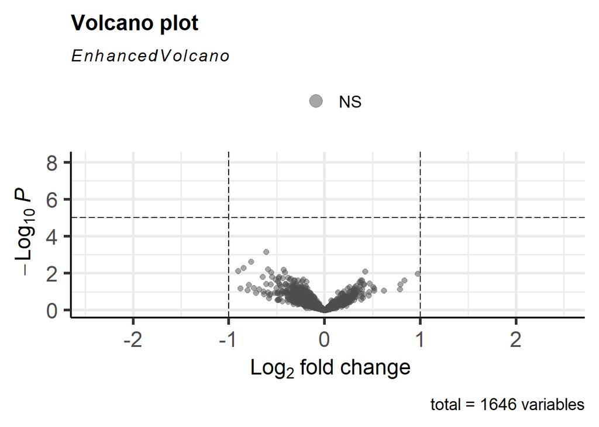

```r
EnhancedVolcano(merge_result,
    lab = merge_result$gene_name,
    x = 'logFC',
    y = 'P.Value')
```

#### Volcano Plot based on FDR.

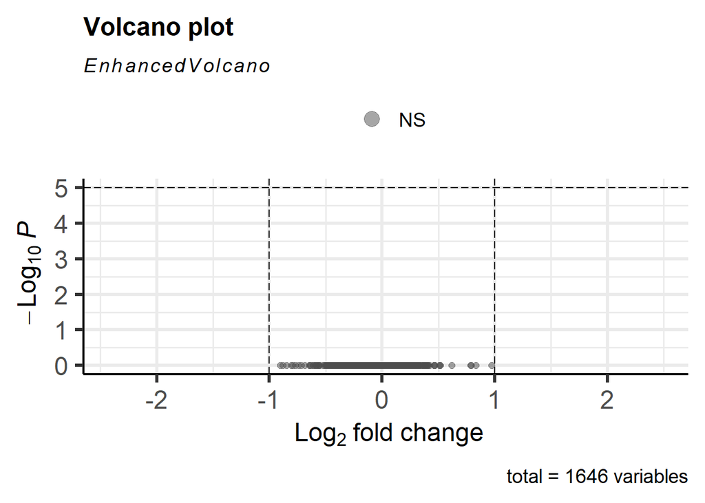

```r
EnhancedVolcano(merge_result,
    lab = merge_result$gene_name,
    x = 'logFC',
    y = 'adj.P.Val')
```

### 4. Figure 1(a) of paper

- First 1.(a)_RNA cohort in different institutions.

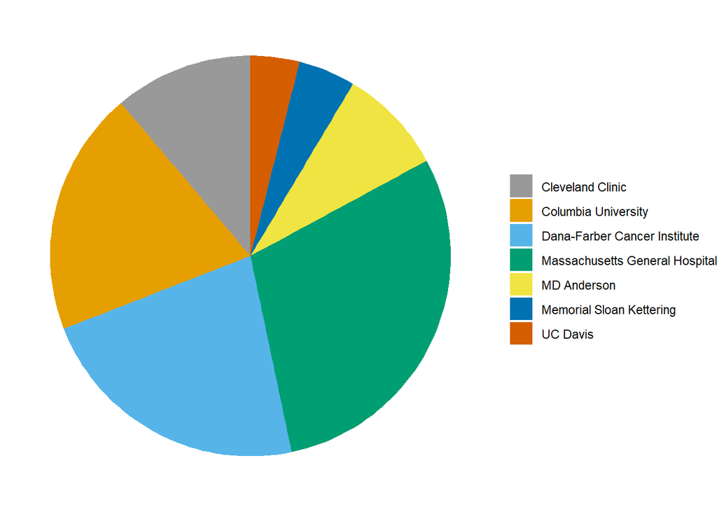

```r
clin <- data.frame(colData(mae))
clin_subset <-clin[,c("Institution","rna")]


# Counting the occurrences of each institution
institution_counts <- table(clin_subset$Institution)

# Creating the pie chart
pie_chart <- ggplot(clin_subset, aes(x = "", fill = factor(Institution))) +
  geom_bar(width = 1, stat = "count") +
  coord_polar("y", start = 0) +
  theme_void() +
  theme(legend.title = element_blank()) +
  scale_fill_manual(values = c("#999999", "#E69F00", "#56B4E9",
                               "#009E73", "#F0E442", "#0072B2",
                               "#D55E00", "#CC79A7", "#999999",
                               "#999999", "#999999", "#999999",
                               "#999999", "#999999", "#999999"))

# Printing the pie chart
print(pie_chart)
```

### 5. Figure 1(b) of paper

.Figure 1(b):BOR/recist by PDL1 TPS category.

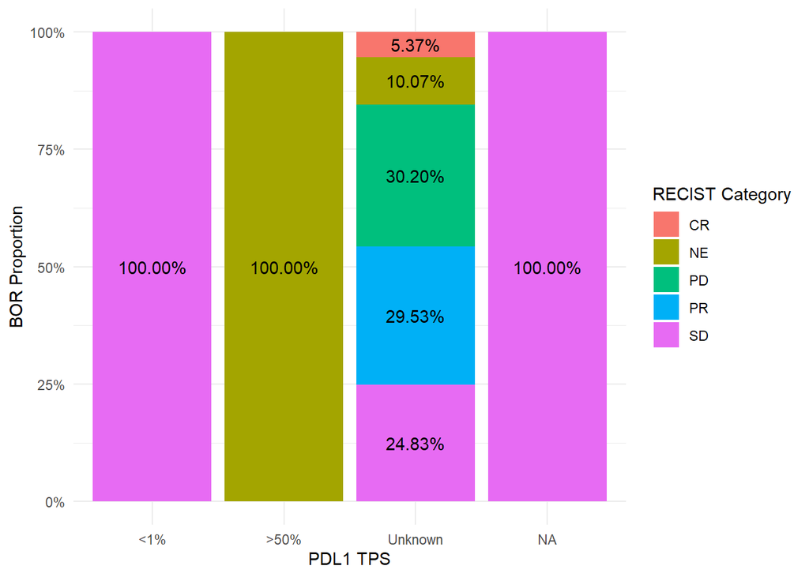

```r
# Select only the necessary columns
clin <- clin[, c("PDL1_TPS_Description", "recist", "PDL1_TPS")]

# Convert NA values to a specific level
clin$PDL1_TPS_Description <- forcats::fct_explicit_na(clin$PDL1_TPS_Description, na_level = "Unknown")
clin$PDL1_TPS_Description <- factor(clin$PDL1_TPS_Description, levels = c("<1%", "1-49%", ">50%", "Unknown"))

clin$recist <- forcats::fct_explicit_na(clin$recist, na_level = "NE")

# Count the occurrences of combinations of 'PDL1_TPS_Description' and 'recist'
# Note: Do not quote the column names
counted_data <- dplyr::count(clin, PDL1_TPS_Description, recist)

# Group by 'PDL1_TPS_Description' and calculate frequencies
grouped_data <- group_by(counted_data, PDL1_TPS_Description)
data_summary <- mutate(grouped_data, freq = n / sum(n))

# Plotting
ggplot(data_summary, aes(x = PDL1_TPS_Description, y = freq, fill = recist)) +
  geom_bar(stat = "identity") +
  scale_y_continuous(labels = scales::percent) +
  labs(x = "PDL1 TPS", y = "BOR Proportion", fill = "RECIST Category") +
  geom_text(aes(label = scales::percent(freq)), position = position_stack(vjust = 0.5)) +
  theme_minimal()
```